# Evaluacion Patron De Mortalidad

## Preparar datos para análisis

La base de datos tiene la variable “FECHA.DATA” que corresponde a los registros de mortalidad mensual durante el 2018. Para que se puedan realizar los análisis en R de esta variable es necesario transformarla desde el formato POSIXct a Fecha con el comando as.Date. Posteriormente, las variables “ESPECIE” y “Areas” se transformarán a factores con el comando as.factor y posteriormente se resumirán los datos de acuerdo a los factores mencionados para conocer el número de observaciones por especie y área.

```r
# Cambiar formato de la variables fecha (FECHA.DATO) de POSIXct a Fecha
Mortalidad$FECHA.DATO <- as.Date(Mortalidad$FECHA.DATO)
str(Mortalidad)
```

[output not shown]

[output cut: 46 more lines]

[output not shown]

```r
# Convertir las variables "ESPECIE" y "Areas" en factores, resumir y mostrar total de datos por Area y Especie
Mortalidad$ESPECIE <- as.factor((Mortalidad$ESPECIE))
Mortalidad$Area <- as.factor((Mortalidad$Area))
summary(Mortalidad)
```

```
##      COD              FECHA.DATO          NUM_INICIAL         NUM_MORT
##  Length:652         Min.   :2018-01-01   Min.   :  15269   Min.   :     0
##  Class :character   1st Qu.:2018-04-01   1st Qu.: 532035   1st Qu.:  1198
##  Mode  :character   Median :2018-07-01   Median : 753114   Median :  2610
##                     Mean   :2018-06-20   Mean   : 754507   Mean   :  5754
##                     3rd Qu.:2018-10-01   3rd Qu.: 930744   3rd Qu.:  4945
##                     Max.   :2018-12-01   Max.   :2283162   Max.   :668967
##     NUM_SRS           NUM_SCA       Area      ESPECIE
##  Min.   :    0.0   Min.   :   0.0   1:147   Coho  :184
##  1st Qu.:    0.0   1st Qu.:  47.5   3:146   Salar :348
##  Median :    5.0   Median : 154.0   4: 94   Trucha:120
##  Mean   :  832.0   Mean   : 465.6   5:265
##  3rd Qu.:  214.2   3rd Qu.: 411.8
##  Max.   :68308.0   Max.   :9777.0
```

```r
Mortalidad %>% group_by(ESPECIE) %>% summarise(n = n())
```

```
## # A tibble: 3 × 2
##   ESPECIE     n
##   <fct>   <int>
## 1 Coho      184
## 2 Salar     348
## 3 Trucha    120
```

```r
Mortalidad %>% group_by(Area) %>% summarise(n = n())
```

```
## # A tibble: 4 × 2
##   Area      n
##   <fct> <int>
## 1 1       147
## 2 3       146
## 3 4        94
## 4 5       265
```

## Crear nuevas variables de mortalidad y analizar distribucion de los datos

Para el análisis de mortalidad se uso un índice de mortalidad en porcentaje para cada una de las variables de mortalidad total, por SRS y SCA. Para esto se crearon nuevas variables usando la función “mutate”. Posteriormente, se analizó la distribución de cada uno de las nuevas variables por medio de histogramas por especies. Donde se evidenció que la distribución de los datos es de tipo binomial negativa.

```r
# Crear variable Mortalidad Total (Mort_T)
Mortalidad <- Mortalidad %>% mutate (Mort_T = (NUM_MORT/NUM_INICIAL*100))
str(Mortalidad$Mort_T)
```

```
##  num [1:652] 1.217 0.409 0.131 0.703 0.619 ...
```

```r
# Crear variable Mortalidad por SRS (Mort_SRS)
Mortalidad <- Mortalidad %>% mutate (Mort_SRS = (NUM_SRS/NUM_INICIAL*100))
str(Mortalidad$Mort_SRS)
```

```
##  num [1:652] 0 0 0 0 0 ...
```

```r
# Crear variable Mortalidad sin causa aparente (Mort_SCA)
Mortalidad <- Mortalidad %>% mutate (Mort_SCA = (NUM_SCA/NUM_INICIAL*100))
str(Mortalidad$Mort_SCA)
```

```
##  num [1:652] 0.00367 0.02538 0.01088 0.00204 0.00141 ...
```

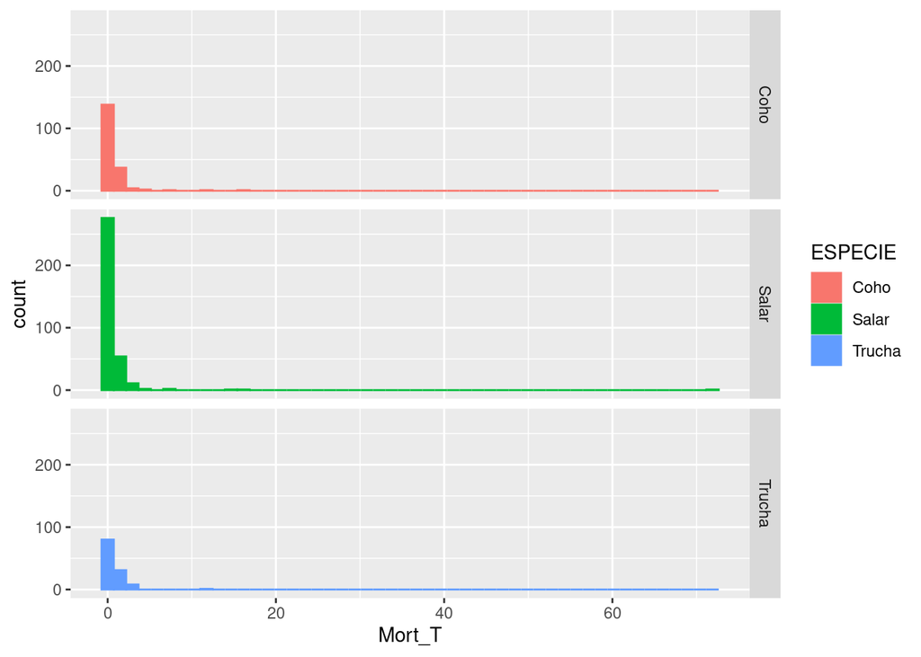

```r
# Evaluacion de las variables con histogramas por especie (Coho y Salmon) y
# tipo de mortalidad (Total, SRS y SCA)

Plot_Histog_Especie_Mort_T <- ggplot(Mortalidad, aes(Mort_T, color = ESPECIE, fill = ESPECIE)) + geom_histogram(position="identity",  bins = 50)
Plot_Histog_Especie_Mort_T + facet_grid(ESPECIE ~ .)
```

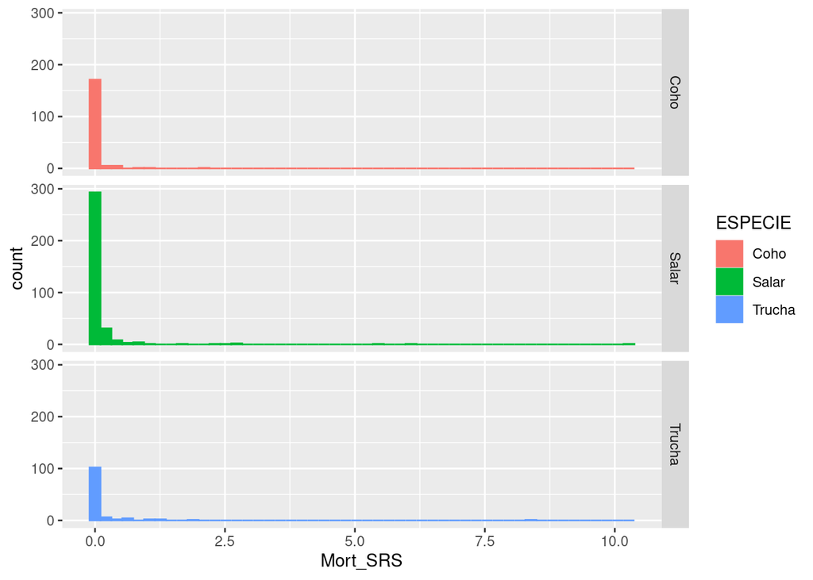

```r
Plot_Histog_Especie_SRS <- ggplot(Mortalidad, aes(Mort_SRS, color = ESPECIE, fill = ESPECIE)) + geom_histogram(position="identity",  bins = 50)
Plot_Histog_Especie_SRS + facet_grid(ESPECIE ~ .)
```

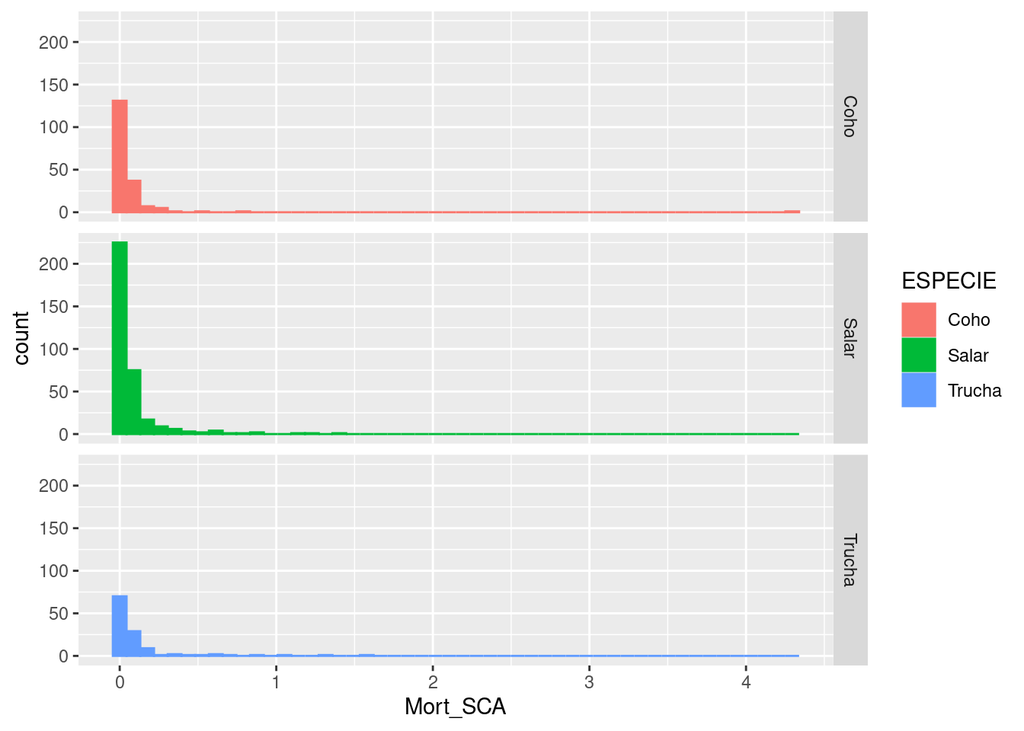

```r
Plot_Histog_Especie_SCA <- ggplot(Mortalidad, aes(Mort_SCA, color = ESPECIE, fill = ESPECIE)) + geom_histogram(position="identity",  bins = 50)
Plot_Histog_Especie_SCA + facet_grid(ESPECIE ~ .)
```

# Crear Tabla de Frecuencia por Area Se creo una tabla de frecuencia por Area y especie la cual indica que solo los grupo de Salar y Coho tienen datos en todas las areas. ientyras que el grupo de Truchas tiene solo centros en las areas 1 y 5

```r
# Tabla de Frecuencia con variables Area y Especie

CrossTable(Mortalidad$ESPECIE, Mortalidad$Area, prop.t=TRUE, prop.r=TRUE, prop.c=TRUE)
```

```
##
##
##    Cell Contents
## |-------------------------|
## |                       N |
## | Chi-square contribution |
## |           N / Row Total |
## |           N / Col Total |
## |         N / Table Total |
## |-------------------------|
##
##
## Total Observations in Table:  652
##
##
##                    | Mortalidad$Area
## Mortalidad$ESPECIE |         1 |         3 |         4 |         5 | Row Total |
## -------------------|-----------|-----------|-----------|-----------|-----------|
##               Coho |        28 |        62 |        54 |        40 |       184 |
##                    |     4.383 |    10.498 |    28.451 |    16.180 |           |
##                    |     0.152 |     0.337 |     0.293 |     0.217 |     0.282 |
##                    |     0.190 |     0.425 |     0.574 |     0.151 |           |
##                    |     0.043 |     0.095 |     0.083 |     0.061 |           |
## -------------------|-----------|-----------|-----------|-----------|-----------|
##              Salar |        11 |        84 |        40 |       213 |       348 |
##                    |    58.002 |     0.473 |     2.062 |    36.203 |           |
##                    |     0.032 |     0.241 |     0.115 |     0.612 |     0.534 |
##                    |     0.075 |     0.575 |     0.426 |     0.804 |           |
##                    |     0.017 |     0.129 |     0.061 |     0.327 |           |
## -------------------|-----------|-----------|-----------|-----------|-----------|
##             Trucha |       108 |         0 |         0 |        12 |       120 |
##                    |   242.174 |    26.871 |    17.301 |    27.725 |           |
##                    |     0.900 |     0.000 |     0.000 |     0.100 |     0.184 |
##                    |     0.735 |     0.000 |     0.000 |     0.045 |           |
##                    |     0.166 |     0.000 |     0.000 |     0.018 |           |
## -------------------|-----------|-----------|-----------|-----------|-----------|
##       Column Total |       147 |       146 |        94 |       265 |       652 |
##                    |     0.225 |     0.224 |     0.144 |     0.406 |           |
## -------------------|-----------|-----------|-----------|-----------|-----------|
##
##
```

# Comparar datos de mortalidad por especie y area por medio de boxplots

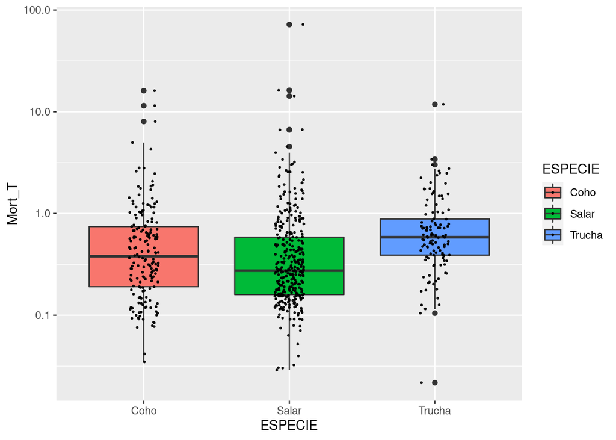

```r
# Graficar Mortalidad Total por especie
BoxPlot_Mort_T_Especie <- ggplot(Mortalidad, aes(x=ESPECIE, y=Mort_T, fill=ESPECIE)) + geom_boxplot()
BoxPlot_Mort_T_Especie + scale_y_continuous(trans = log10_trans())+
  geom_jitter(color="black", size=0.4, alpha=0.9, position=position_jitter(0.1))
```

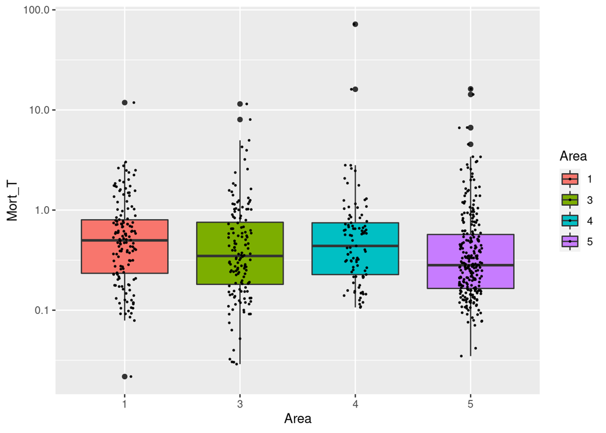

```r
# Graficar Mortalidad Total por Area

BoxPlot_Mort_T_Area <- ggplot(Mortalidad, aes(x=Area, y=Mort_T, fill=Area, group=Area)) + geom_boxplot()
BoxPlot_Mort_T_Area + scale_y_continuous(trans = log10_trans()) +
  geom_jitter(color="black", size=0.4, alpha=0.9, position=position_jitter(0.1))
```

```r
# Graficar de tiempo para la variable mortalidad por especie

PlotTiempo_Mort_T <- ggplot(Mortalidad, aes(x = FECHA.DATO, y = Mort_T)) +
           geom_bar(position='dodge', stat='identity') +
           facet_wrap(~ ESPECIE, scale = "free_y", ncol = 1)

PlotTiempo_Mort_T + scale_y_log10()
```

[output not shown]

```r
PlotTiempo_Mort_SCA <- ggplot(Mortalidad, aes(x = FECHA.DATO, y = Mort_T)) +
           geom_bar(position='dodge', stat='identity') +
           facet_wrap(~ ESPECIE, scale = "free_y", ncol = 1)

PlotTiempo_Mort_SCA + scale_y_log10()
```

[output not shown]

```r
PlotTiempo_Mort_SRS <- ggplot(Mortalidad, aes(x = FECHA.DATO, y = Mort_T)) +
           geom_bar(position='dodge', stat='identity') +
           facet_wrap(~ ESPECIE, scale = "free_y", ncol = 1)

PlotTiempo_Mort_SRS + scale_y_log10()
```

[output not shown]